# Learner_Notebook

## Exploratory Data Analysis With Python and Pandas

### Libraries

```python
import pandas as pd
import numpy as np
import matplotlib.pyplot as plt
import seaborn as sns
from scipy.stats import gaussian_kde
import calmap
from ydata_profiling import ProfileReport
```

**Context**

The growth of supermarkets in most populated cities are increasing and market competitions are also high. The dataset is one of the historical sales of supermarket company which has recorded in 3 different branches for 3 months data.

**Data Dictionary**

1. ***Invoice id:*** Computer generated sales slip invoice identification number
2. ***Branch:*** Branch of supercenter (3 branches are available identified by A, B and C).
3. ***City:*** Location of supercenters
4. ***Customer type:*** Type of customers, recorded by Members for customers using member card and Normal for without member card.
5. ***Gender:*** Gender type of customer
6. ***Product line:*** General item categorization groups - Electronic accessories, Fashion accessories, Food and beverages, Health and beauty, Home and lifestyle, Sports and travel
7. ***Unit price:*** Price of each product in USD
8. ***Quantity:*** Number of products purchased by customer
9. ***Tax:*** 5% tax fee for customer buying
10. ***Total:*** Total price including tax
11. ***Date:*** Date of purchase (Record available from January 2019 to March 2019)
12. ***Time:*** Purchase time (10am to 9pm)
13. ***Payment:*** Payment used by customer for purchase (3 methods are available – Cash, Credit card and Ewallet)
14. ***COGS:*** Cost of goods sold
15. ***Gross margin percentage:*** Gross margin percentage
16. ***Gross income:*** Gross income
17. ***Rating:*** Customer stratification rating on their overall shopping experience (On a scale of 1 to 10)

### Initial Data Exploration

```python
df = pd.read_csv('supermarket_sales.csv')
```

```python
df.head(20)
```

[output not shown]

```python
df.columns
```

```
Index(['Invoice ID', 'Branch', 'City', 'Customer type', 'Gender',
       'Product line', 'Unit price', 'Quantity', 'Tax 5%', 'Total', 'Date',
       'Time', 'Payment', 'cogs', 'gross margin percentage', 'gross income',
       'Rating'],
      dtype='object')
```

```python
df.dtypes
```

```
Invoice ID                  object
Branch                      object
City                        object
Customer type               object
Gender                      object
Product line                object
Unit price                 float64
Quantity                   float64
Tax 5%                     float64
Total                      float64
Date                        object
Time                        object
Payment                     object
cogs                       float64
gross margin percentage    float64
gross income               float64
Rating                     float64
dtype: object
```

```python
df['Date']
```

```
0        1/5/19
1        3/8/19
2        3/3/19
3       1/27/19
4        2/8/19
         ...
998     2/22/19
999     2/18/19
1000    2/18/19
1001    3/10/19
1002    1/26/19
Name: Date, Length: 1003, dtype: object
```

```python
df['Date']= pd.to_datetime(df['Date'])
```

```python
df.dtypes
```

```
Invoice ID                         object
Branch                             object
City                               object
Customer type                      object
Gender                             object
Product line                       object
Unit price                        float64
Quantity                          float64
Tax 5%                            float64
Total                             float64
Date                       datetime64[ns]
Time                               object
Payment                            object
cogs                              float64
gross margin percentage           float64
gross income                      float64
Rating                            float64
dtype: object
```

```python
df.set_index('Date',inplace=True)
```

```python
df.describe()
```

|  | Unit price | Quantity | Tax 5% | Total | cogs | gross margin percentage | gross income | Rating |
| --- | --- | --- | --- | --- | --- | --- | --- | --- |
| count | 996.000000 | 983.000000 | 1003.000000 | 1003.000000 | 1003.000000 | 1.003000e+03 | 1003.000000 | 1003.000000 |
| mean | 55.764568 | 5.501526 | 15.400368 | 323.407726 | 308.007358 | 4.761905e+00 | 15.400368 | 6.972682 |
| std | 26.510165 | 2.924673 | 11.715192 | 246.019028 | 234.303836 | 8.886215e-16 | 11.715192 | 1.717647 |
| min | 10.080000 | 1.000000 | 0.508500 | 10.678500 | 10.170000 | 4.761905e+00 | 0.508500 | 4.000000 |
| 25% | 33.125000 | 3.000000 | 5.894750 | 123.789750 | 117.895000 | 4.761905e+00 | 5.894750 | 5.500000 |
| 50% | 55.420000 | 5.000000 | 12.096000 | 254.016000 | 241.920000 | 4.761905e+00 | 12.096000 | 7.000000 |
| 75% | 78.085000 | 8.000000 | 22.539500 | 473.329500 | 450.790000 | 4.761905e+00 | 22.539500 | 8.500000 |
| max | 99.960000 | 10.000000 | 49.650000 | 1042.650000 | 993.000000 | 4.761905e+00 | 49.650000 | 10.000000 |

### Univariate Analysis

**Question:** What does the distribution of customer ratings looks like? Is it skewed?

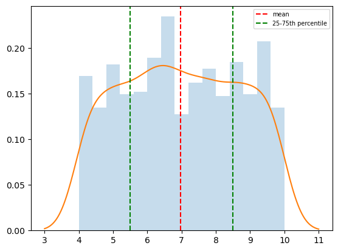

```python
plt.hist(df['Rating'].dropna(), bins=15, density=True, alpha=0.25)
kde = gaussian_kde(df['Rating'])
x_vals = np.linspace(df['Rating'].min() -1, df['Rating'].max() +1, 200)
plt.plot(x_vals, kde(x_vals))
plt.axvline(x=np.mean(df['Rating']), c='red', ls='--', label='mean')
plt.axvline(x=np.percentile(df['Rating'], 25),c='green', ls='--',label='25-75th percentile')
plt.axvline(x=np.percentile(df['Rating'],75),c='green', ls='--')
plt.legend(fontsize=7, loc='upper right')
plt.show()
```

**Question:** Do aggregate sales numbers differ by much between branches?

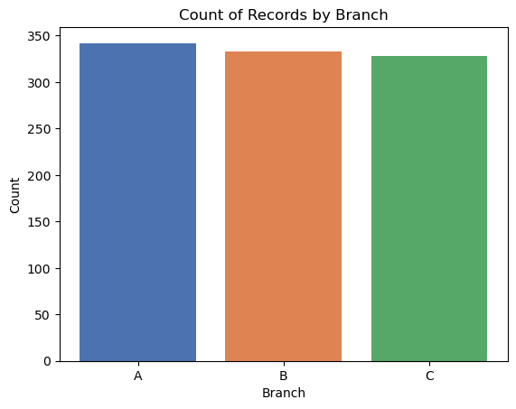

```python
colors = ['#4C72B0', '#DD8452', '#55A868']
branch_counts = df['Branch'].value_counts()
plt.bar(branch_counts.index, branch_counts.values)
plt.bar(branch_counts.index, branch_counts.values, color=colors)
plt.xlabel('Branch')
plt.ylabel('Count')
plt.title('Count of Records by Branch')
plt.show()
```

### Dealing With Duplicate Rows and Missing Values

```python
df.duplicated().sum()
```

```
3
```

```python
df[df.duplicated()==True]
```

| Date | Invoice ID | Branch | City | Customer type | Gender | Product line | Unit price | Quantity | Tax 5% | Total | Time | Payment | cogs | gross margin percentage | gross income | Rating |
| --- | --- | --- | --- | --- | --- | --- | --- | --- | --- | --- | --- | --- | --- | --- | --- | --- |
| 2019-02-18 | 849-09-3807 | A | Yangon | Member | Female | Fashion accessories | 88.34 | 7.0 | 30.919 | 649.299 | 13:28 | Cash | 618.38 | 4.761905 | 30.919 | 6.6 |
| 2019-03-10 | 745-74-0715 | A | Yangon | Normal | Male | Electronic accessories | NaN | 2.0 | 5.803 | 121.863 | 20:46 | Ewallet | 116.06 | 4.761905 | 5.803 | 8.8 |
| 2019-01-26 | 452-04-8808 | B | Mandalay | Normal | Male | Electronic accessories | 87.08 | NaN | 30.478 | 640.038 | 15:17 | Cash | 609.56 | 4.761905 | 30.478 | 5.5 |

```python
df.drop_duplicates(inplace=True)
```

```python
df.duplicated().sum()
```

```
0
```

```python
df.isna().sum()
```

```
Invoice ID                  0
Branch                      0
City                        0
Customer type              79
Gender                      0
Product line               43
Unit price                  6
Quantity                   19
Tax 5%                      0
Total                       0
Time                        0
Payment                     0
cogs                        0
gross margin percentage     0
gross income                0
Rating                      0
dtype: int64
```

```python
df.isna().sum()/len(df)
```

```
Invoice ID                 0.000
Branch                     0.000
City                       0.000
Customer type              0.079
Gender                     0.000
Product line               0.043
Unit price                 0.006
Quantity                   0.019
Tax 5%                     0.000
Total                      0.000
Time                       0.000
Payment                    0.000
cogs                       0.000
gross margin percentage    0.000
gross income               0.000
Rating                     0.000
dtype: float64
```

```python
df.fillna(df.mode().iloc[0], inplace=True)
```

```python
df.isna().sum()
```

```
Invoice ID                 0
Branch                     0
City                       0
Customer type              0
Gender                     0
Product line               0
Unit price                 0
Quantity                   0
Tax 5%                     0
Total                      0
Time                       0
Payment                    0
cogs                       0
gross margin percentage    0
gross income               0
Rating                     0
dtype: int64
```

```python
#Alternatively, we could use the code below to get a
#full report if the dataset is small:
dataset= pd.read_csv('supermarket_sales.csv')
prof = ProfileReport(dataset)
prof
```

[output not shown]

### Correlation Analysis

```python
round(np.corrcoef(df['gross income'], df['Rating']) [1][0],2)
#Correlation close to 0 indicates no meaningful linear relationship, Customer ratings
#are likely independent of gross income.
```

```
-0.04
```

```python
np.round(df.corr(numeric_only=True),2)
```

|  | Unit price | Quantity | Tax 5% | Total | cogs | gross margin percentage | gross income | Rating |
| --- | --- | --- | --- | --- | --- | --- | --- | --- |
| Unit price | 1.00 | 0.01 | 0.62 | 0.62 | 0.62 | NaN | 0.62 | -0.01 |
| Quantity | 0.01 | 1.00 | 0.69 | 0.69 | 0.69 | NaN | 0.69 | -0.01 |
| Tax 5% | 0.62 | 0.69 | 1.00 | 1.00 | 1.00 | NaN | 1.00 | -0.04 |
| Total | 0.62 | 0.69 | 1.00 | 1.00 | 1.00 | NaN | 1.00 | -0.04 |
| cogs | 0.62 | 0.69 | 1.00 | 1.00 | 1.00 | NaN | 1.00 | -0.04 |
| gross margin percentage | NaN | NaN | NaN | NaN | NaN | NaN | NaN | NaN |
| gross income | 0.62 | 0.69 | 1.00 | 1.00 | 1.00 | NaN | 1.00 | -0.04 |
| Rating | -0.01 | -0.01 | -0.04 | -0.04 | -0.04 | NaN | -0.04 | 1.00 |

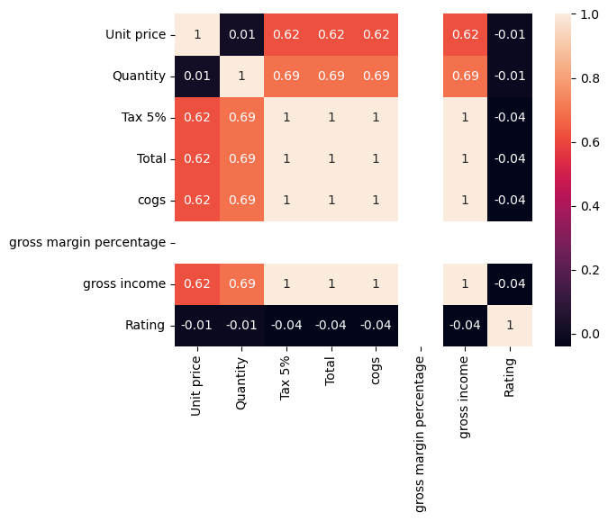

```python
sns.heatmap(np.round(df.corr(numeric_only=True),2), annot=True)
```